# TDR8 Graphiques et variables

V. Tolon, V. Payet & J. Martin

28 avril 2021

**Objectifs** : Nous allons découvrir les différents types de graphiques adaptés aux différents types et nombre de variables. A chaque fois seront proposés un graphique de base et un graphique customisé.

[figure not shown]

# 1 **Variables qualitatives**

## 1.1 **Graphique en barre**

On utilise les ici données `cars93` de la librairie très utile `MASS` que nous allons installer puis explorer. Elles contiennent des données sur des modèles de voitures de 1993 avec leur caractéristiques.

```r
install.packages("MASS") # n'oubliez pas de désactiver cette ligne après l'installation
library(MASS)
data(Cars93)
Cars93[1:4 , 1:7]
```

```
##   Manufacturer   Model    Type Min.Price Price Max.Price MPG.city
## 1        Acura Integra   Small      12.9  15.9      18.8       25
## 2        Acura  Legend Midsize      29.2  33.9      38.7       18
## 3         Audi      90 Compact      25.9  29.1      32.3       20
## 4         Audi     100 Midsize      30.8  37.7      44.6       19
```

**Exercice :** combien de `Type` existe-t-il ? Dénombrez le nombre de modèles pour chaque type.

```r
tabT <- table(Cars93$Type) # que fait table ?
tabT
##
## Compact   Large Midsize   Small  Sporty     Van
##      16      11      22      21      14       9
```

Voyons l’usage de la fonction `barplot()` pour représenter ce résultat :

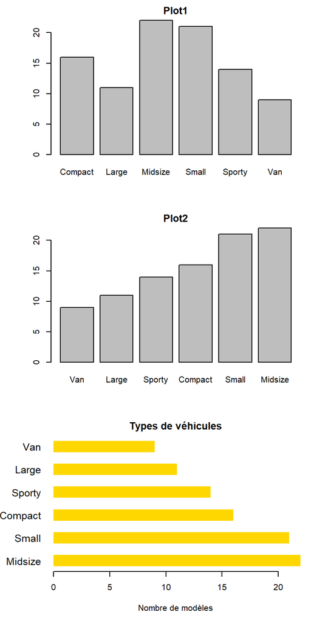

```r
par(mfrow=c(3, 1), mar=c(5, 5, 2, 1))

barplot(tabT, main="Plot1")

barplot(sort(tabT), main="Plot2")

barplot(rev(sort(tabT)), main="Types de véhicules", las=1,  horiz=T,
        cex.names=1.2, col="gold", border=NA, space=1,
        xlab="Nombre de modèles")
```

## 1.2 **Croisement de deux qualitatives**

**Exercice :** Affichez les noms des variables. Ajoutez dans l’usage précédent de la fonction `table` la variable d’origine du véhicule afin de réaliser un tableau croisé Type-Origine avec les dénombrements dans chaque case.

```r
names(Cars93)
# Repèrez la variable Origin
```

```r
tabTO <- table(Cars93$Type, Cars93$Origin)
tabTO
##
##           USA non-USA
##   Compact   7       9
##   Large    11       0
##   Midsize  10      12
##   Small     7      14
##   Sporty    8       6
##   Van       5       4
```

Pour représenter ceci on peut utiliser ici la fonction `plot()` ou à nouveau `barplot()` :

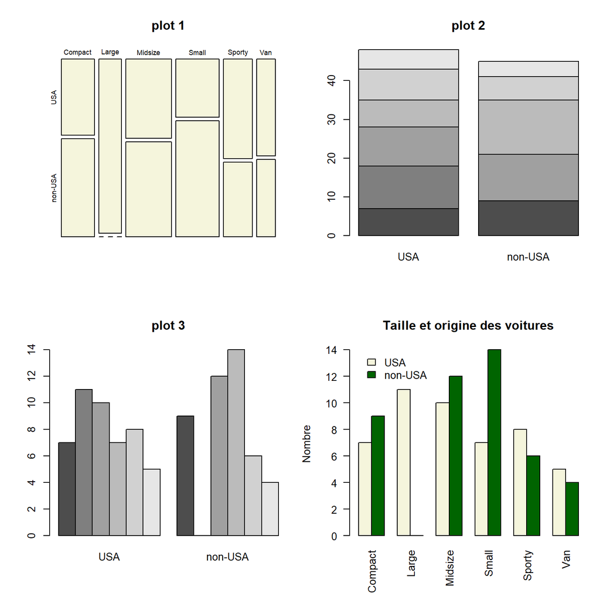

```r
par(mfrow=c(2, 2), mar=c(5, 4, 4, 1))

plot(tabTO, main="plot 1", col="beige") # taille des rectangles proportionnelle à l'effectif

barplot(tabTO, main="plot 2") # peu lisible

barplot(tabTO, main="plot 3", beside=T) # mieux mais pas de légende
#on voudrait aussi mettre les types en abscisse et non l'origine

barplot(t(tabTO), main="Taille et origine des voitures",
        beside=T, col=c("beige", "darkgreen"), las=2,
        ylab="Nombre")
# que fait t()?
legend(1, 14, levels(Cars93$Origin), fill=c("beige", "darkgreen"), bty="n")
```

# 2 **Une variable quantitative**

Avec une seule variable quantitative le graphique permettra surtout d’étudier sa distribution.

## 2.1 **Graphique en bâtons** (variable discrète)

**Exercice :** Importez les données *t3var.txt*. Avec `table()` trouvez le nombre d’étudiants correspondant à chaque valeur de taille. Stockez ces résultats dans un objet sur lequel vous appliquerez la fonction `plot()` permettant de produire ce graphique :

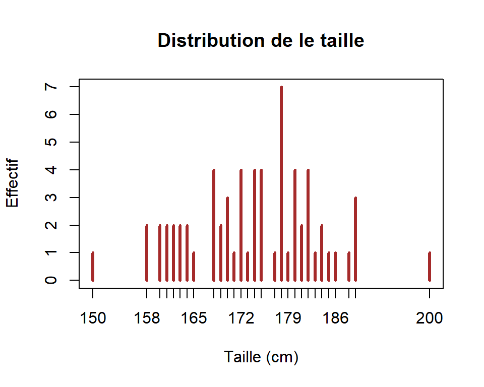

```r
t3var <- read.table("t3var.txt", header=TRUE,stringsAsFactors = TRUE)
tabP <- table(t3var$tai)
plot(tabP, main="Distribution de le taille",
     ylab="Effectif",  xlab="Taille (cm)",
     col="brown", lwd=3)
```

## 2.2 **Histogrammes** (variable continue)

**Exercice :** Essayez d’appliquer la fonction `hist()` sur le poids des étudiants. Quelle est la différence entre les échelles des deux graphiques ? De quelle option provient-elle ? Essayez de modifier `adjust` dans le second graphique.

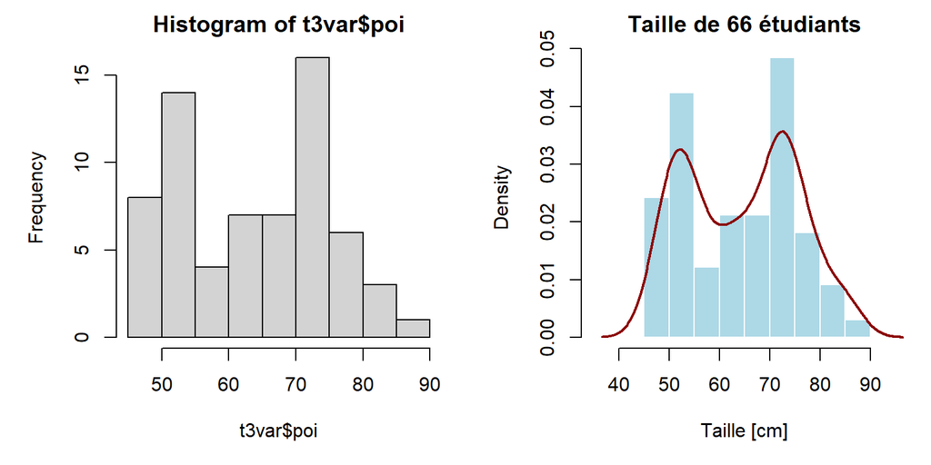

```r
par(mfrow=c(1, 2), mar=c(5, 5, 2, 1))

hist(t3var$poi)

hist(t3var$poi, col = "lightblue", border = "white",
main = paste("Taille de", nrow(t3var), "étudiants"),
xlab = "Taille [cm]", nclass=10, proba=T, xlim=c(35, 95))

lines(density(t3var$poi, adjust=0.8), lwd = 2,col="darkred")
```

# 3 **Une quali et une quanti**

## 3.1 **Le Boxplot** (fort effectif)

Le boxplot est très utile car il permet d’étudier les différences de moyennes entre des modalités (des groupes) en observant également l’ampleur des variations existantes autour de ces moyennes ainsi que la forme des distributions. C’est donc l’outil idéal pour une ANOVA 1 ou 2.

**Exercice :** Avec les données `Cars93`, essayez d’appliquer la fonction `boxplot()` avec les variables `Price` et `DriveTrain` (traction, propulsion, $4\times4$). Regardez l’aide de la fonction `boxplot()` pour comprendre son usage. Améliorez les graphiques. Observez comment on utilise deux facteurs en même temps (pour une ANOVA2 par exemple) en ajoutant la variable `Origin`.

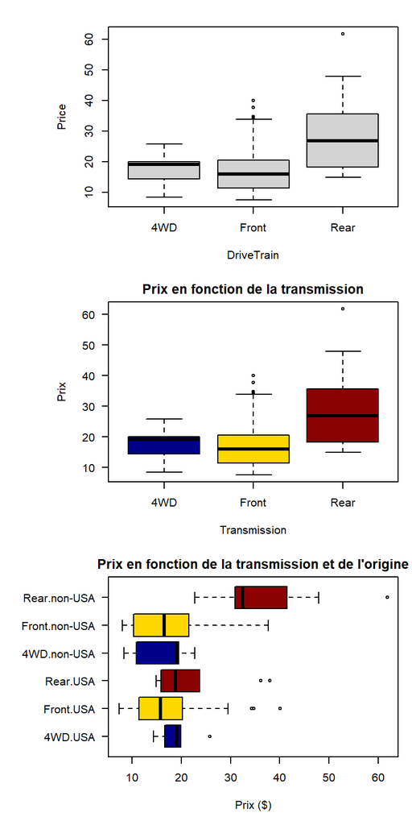

```r
par(mfrow=c(3, 1), mar=c(5, 8, 2, 1))

boxplot(Price~DriveTrain, data=Cars93)

boxplot(Price~DriveTrain, data=Cars93,  col = c("darkblue", "gold", "darkred"),
main = paste("Prix en fonction de la transmission"),
ylab = "Prix", xlab="Transmission", las = 1)

boxplot(Price~DriveTrain*Origin, data=Cars93,  col = c("darkblue", "gold", "darkred"),
main = paste("Prix en fonction de la transmission et de l'origine"),
ylab = NA,  xlab="Prix ($)", las = 1, notch = F, horizontal=T)
```

## 3.2 Le Stripchart (faible effectif)

Ce graphique très simple (avec peu de données) permet de voir l’intégralité des données.

**Exercice :** Reproduisez le même exemple que le précédent mais en utilisant la fonction `stripchart()`. En cas de superposition des points il faut bruiter les données avec l’option `method="jitter"`.

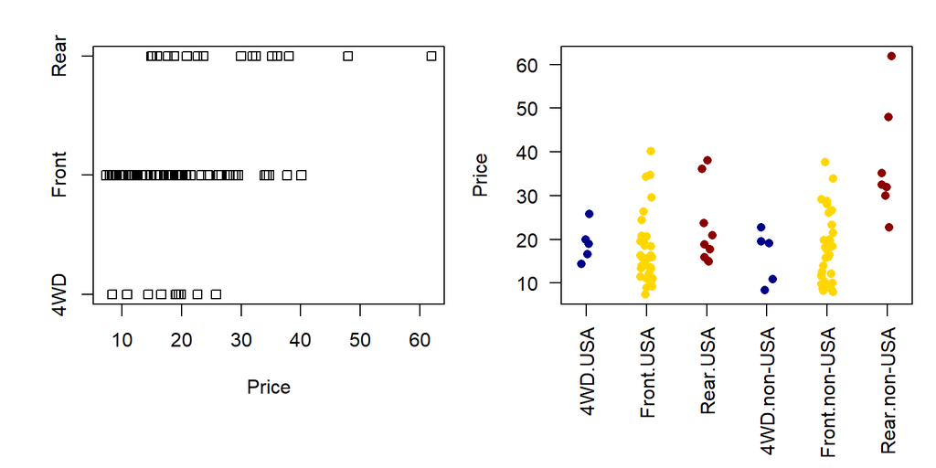

```r
par(mfrow=c(1, 2), mar=c(7, 4, 2, 1))

stripchart(Price~DriveTrain, data=Cars93)

stripchart(Price~DriveTrain*Origin, data=Cars93, vertical=T,
           method="jitter", jitter=0.1, pch=16, cex=1,
           col=c("darkblue", "gold", "darkred"), las=2)
```

## 3.3 Moyenne +/ écart-type

Bien que ce graphique soit très utilisé, il n’existe pas de fonction prédéterminées pour représenter des moyennes avec des barres d’erreur. Il est néanmoins possible d’utiliser les fonctions de customisation graphiques pour y arriver. Nous allons créer une fonction que vous pouvez découvrir ci-dessous :

```r
plotME <- function(y, fac, col="black", cex=1, pch=16, lwd=1, lty=1, ylab="y") {
  meay<-tapply(y, fac, mean)          # la moyenne par groupe
  sdy<-tapply(y, fac, sd)             # l'écart-type par groupe
  x<-1:nlevels(fac)                 # la position des moyenne sur x
  stripchart(y~fac, cex=0, vertical=T, las=2, ylab=ylab)  # un graphique vide
  points(x, meay, pch=pch, col=col, cex=cex)      # on place les points
  arrows(x, meay-sdy, x, meay+sdy, col=col, lwd=lwd, lty=lty, code=3, angle=90, le=0.05) # les barres d'erreur

}
```

**Exercice :** Copiez et collez cette fonction dans votre script puis implémentez la dans la console. Utilisez la sur les données `cars93` pour réaliser des graphiques moyenne +/- écart-type du prix en fonction d’une variable qualitative au choix.

- Optionnel : Cette fonction est déjà présente dans le fichier *fonctions_TD.R*. Utilisez `source()` pour charger toutes les fonctions de ce fichier. Utilisez ensuite votre fonction `plotME()`.

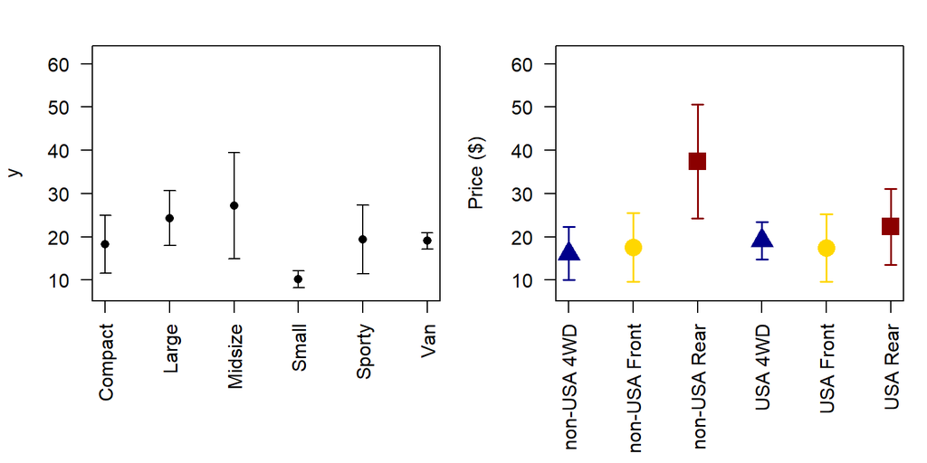

```r
source("fonctions_TD.R") # optionnel

par(mfrow=c(1, 2), mar=c(7, 4, 2, 1))

plotME(Cars93$Price, Cars93$Type)
plotME(Cars93$Price, factor(paste(Cars93$Origin, Cars93$DriveTrain)),
       col=c("darkblue", "gold", "darkred"), pch=c(17, 16, 15),
       cex=2, lwd=1.5, ylab="Price ($)")
```

# 4 **Deux quantitatives** : Le nuage de points

Le nuage de point est adapté entre autre aux contextes de régression linéaire simple et multiple. Vous avez déjà produit un graphique en nuage de point assez avancé au TD précédent.

**Exercice :** Utilisez les scripts du TD précédent pour produire un graphique en nuage de points permettant de voir le lien entre le prix des voitures et une ou plusieurs autres variables quantitatives de votre choix. Vous pouvez représenter l’`Origin` avec des couleurs différentes.

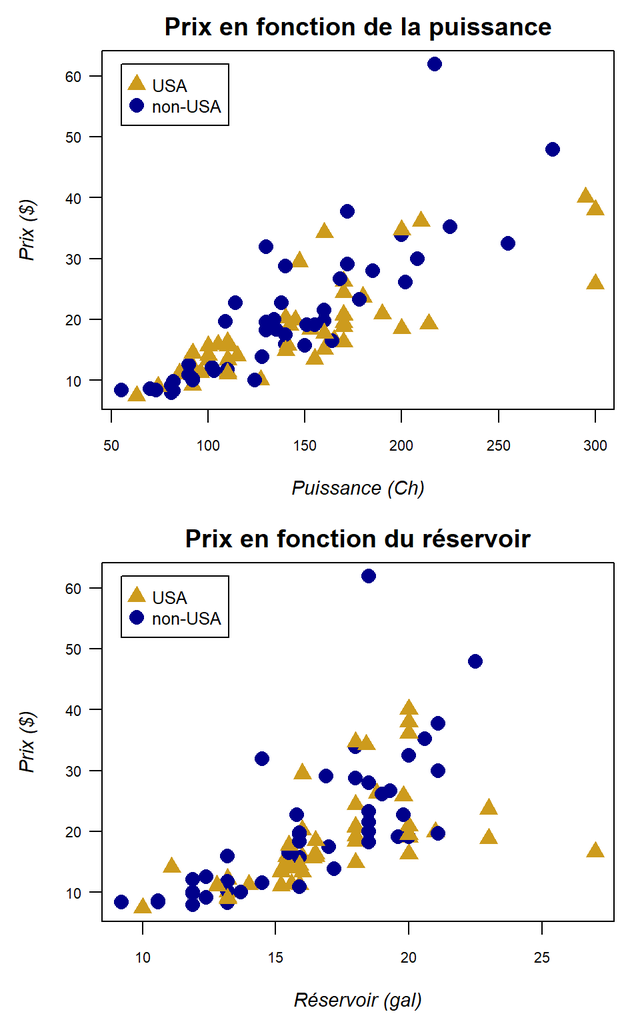

```r
par(mfrow=c(2, 1), mar=c(4, 4, 2, 1),
    mgp=c(2.5, 0.8, 0), las=1,   # positions des éléments des axes
    cex.axis=0.7,               # taille des chiffres des axes
    cex.lab=0.9, font.lab=3,     # taille et police des titres des axes
    font.main=2)               # police du titre


colo<-c("goldenrod3", "darkblue")[as.numeric(Cars93$Origin)]       # des couleurs suivant le sexe
pttype<-c(17, 16)[as.numeric(Cars93$Origin)]

plot(Price~Horsepower, main = "Prix en fonction de la puissance", xlab = "Puissance (Ch)", ylab = "Prix ($)",
     col = colo, pch = pttype, cex = 1.5, data=Cars93)
legend(min(Cars93$Horsepower), max(Cars93$Price),  levels(Cars93$Origin), pch = c(17, 16),
       col = c("goldenrod3", "darkblue"), pt.cex=1.5, cex=0.8)


plot(Price~Fuel.tank.capacity, main = "Prix en fonction du réservoir", xlab = "Réservoir (gal)", ylab = "Prix ($)",
     col = colo, pch = pttype, cex = 1.5, data=Cars93)
legend(min(Cars93$Fuel.tank.capacity), max(Cars93$Price), levels(Cars93$Origin), pch = c(17, 16),
       col = c("goldenrod3", "darkblue"), pt.cex=1.5, cex=0.8)
```